# part_1

```python
corr = df.corr(method='pearson')
corr
```

|  | P_incidence | P_tilt | L_angle | S_slope | P_radius | S_Degree |
| --- | --- | --- | --- | --- | --- | --- |
| P_incidence | 1.000000 | 0.654528 | 0.765998 | 0.797144 | -0.242780 | 0.688755 |
| P_tilt | 0.654528 | 1.000000 | 0.442636 | 0.099575 | 0.039648 | 0.508595 |
| L_angle | 0.765998 | 0.442636 | 1.000000 | 0.660125 | -0.091128 | 0.698910 |
| S_slope | 0.797144 | 0.099575 | 0.660125 | 1.000000 | -0.361406 | 0.508393 |
| P_radius | -0.242780 | 0.039648 | -0.091128 | -0.361406 | 1.000000 | -0.080151 |
| S_Degree | 0.688755 | 0.508595 | 0.698910 | 0.508393 | -0.080151 | 1.000000 |

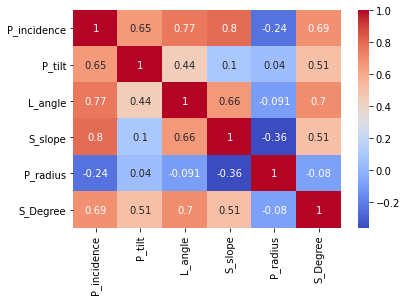

```python
sns.heatmap(df.corr(), annot=True, cmap='coolwarm')
```

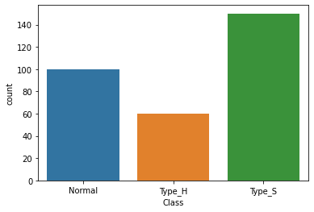

```python
sns.countplot(data=df, x=df["Class"])
```

```python
df["Class"].value_counts(normalize=True)
```

```
Type_S    0.483871
Normal    0.322581
Type_H    0.193548
Name: Class, dtype: float64
```

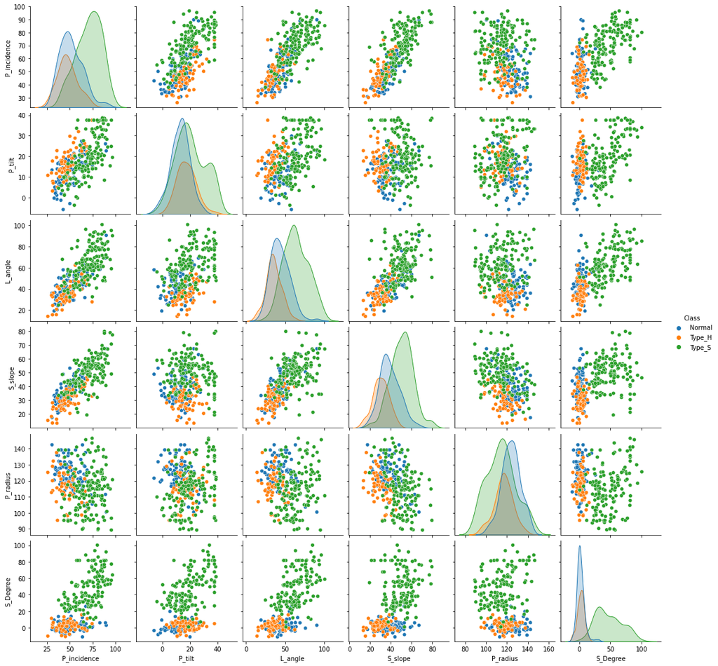

```python
sns.pairplot(data=df, hue="Class");
```

```python
df.info()
```

```
<class 'pandas.core.frame.DataFrame'>
RangeIndex: 310 entries, 0 to 309
Data columns (total 7 columns):
 #   Column       Non-Null Count  Dtype
---  ------       --------------  -----
 0   P_incidence  310 non-null    float64
 1   P_tilt       310 non-null    float64
 2   L_angle      310 non-null    float64
 3   S_slope      310 non-null    float64
 4   P_radius     310 non-null    float64
 5   S_Degree     310 non-null    float64
 6   Class        310 non-null    category
dtypes: category(1), float64(6)
memory usage: 15.1 KB
```

```python
df.head(3)
```

|  | P_incidence | P_tilt | L_angle | S_slope | P_radius | S_Degree | Class |
| --- | --- | --- | --- | --- | --- | --- | --- |
| 0 | 38.505273 | 16.964297 | 35.112814 | 21.540976 | 127.632875 | 7.986683 | Normal |
| 1 | 54.920858 | 18.968430 | 51.601455 | 35.952428 | 125.846646 | 2.001642 | Normal |
| 2 | 44.362490 | 8.945435 | 46.902096 | 35.417055 | 129.220682 | 4.994195 | Normal |

```python
lst = df.drop("Class", axis = 1)
lst.columns
```

```
Index(['P_incidence', 'P_tilt', 'L_angle', 'S_slope', 'P_radius', 'S_Degree'], dtype='object')
```

```python
def bivariate_analysis(col):
    plt.figure()
    print("Distribution of " + col)
    print("----------------------------------------------------------------------------")
    sns.boxplot(data=df, x='Class', y = col);
    plt.show()
```

```
Distribution of P_incidence
----------------------------------------------------------------------------
```

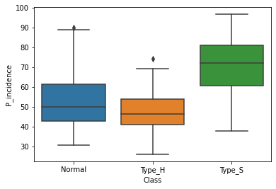

```python
bivariate_analysis("P_incidence")
```

```
Distribution of P_tilt
----------------------------------------------------------------------------
```

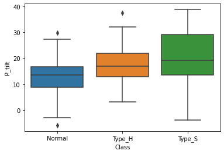

```python
bivariate_analysis("P_tilt")
```

```
Distribution of L_angle
----------------------------------------------------------------------------
```

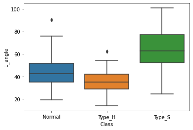

```python
bivariate_analysis("L_angle")
```

```
Distribution of S_slope
----------------------------------------------------------------------------
```

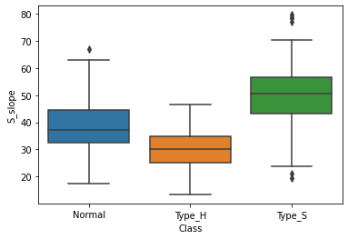

```python
bivariate_analysis("S_slope")
```

```
Distribution of P_radius
----------------------------------------------------------------------------
```

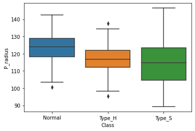

```python
bivariate_analysis("P_radius")
```

```
Distribution of S_Degree
----------------------------------------------------------------------------
```

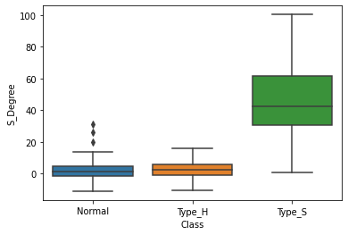

```python
bivariate_analysis("S_Degree")
```

Normal and Type H has small distribution however Type_S is significatnly wider and larger

```python
from sklearn.preprocessing import LabelEncoder

le=LabelEncoder()
df['Class']=le.fit_transform(df['Class'])
df['Class'].value_counts()
```

```
2    150
0    100
1     60
Name: Class, dtype: int64
```

```python
# there is decent corelation among dataset and the target class is imbalanced
```

### 4. Data pre-processing:

• Segregate predictors vs target attributes  
• Perform normalisation or scaling if required.  
• Check for target balancing. Add your comments.  
• Perform train-test split

##### *Here is the approach to finding the best model: 1. We will first create a basic model where K = 1 2. we will then loop through for all values from 1 and 50 and try to find the best accuracy score 3. we will then use grid searchcv to check the mean test scores for the best model*

```python
len(df)
```

```
310
```

```python
# separate the target and features and perform train-test split
X = df.drop(['Class'],axis=1)
y = df['Class']
```

```python
# train test split
from sklearn.model_selection import train_test_split
X_cv, X_test, y_cv, y_test = train_test_split(X, y, test_size=0.30, random_state=42, stratify=y)
```

```python
from sklearn.preprocessing import StandardScaler
from sklearn.neighbors import KNeighborsClassifier
```

```python
# normalize features
scaler = StandardScaler()
scaled_X_cv = scaler.fit_transform(X_cv)
scaled_X_test = scaler.transform(X_test)
```

1. Model training, testing and tuning:  
   • Design and train a KNN classifier.  
   • Display the classification accuracies for train and test data.  
   • Display and explain the classification report in detail.  
   • Automate the task of finding best values of K for KNN.  
   • Apply all the possible tuning techniques to train the best model for the given data. Select the final best trained  
   model with your comments for selecting this model.

```python
print(f"Scaled X cv: {len(scaled_X_cv)}")
print(f"Scaled X TEST: {len(scaled_X_test)}")
print(f"Y_CV: {len(y_cv)}")
print(f"y_test : {len(y_test)}")
```

```
Scaled X cv: 217
Scaled X TEST: 93
Y_CV: 217
y_test : 93
```

```python
# design and train KNN classifier when K = 1
knn_model = KNeighborsClassifier(n_neighbors=1)
knn_model.fit(scaled_X_cv,y_cv)
y_pred = knn_model.predict(scaled_X_test)
```

```python
# model evaluation
```

```python
from sklearn.metrics import classification_report,confusion_matrix,accuracy_score, plot_confusion_matrix
print(f"Accuracy when K = 1: {accuracy_score(y_test,y_pred)}")
```

```
Accuracy when K = 1: 0.8279569892473119
```

```python
print(f"Accuracy of Training Data: {knn_model.score(scaled_X_cv,y_cv)}")
print(f"Accuracy of Test Data: {knn_model.score(scaled_X_test,y_test)}")
```

```
Accuracy of Training Data: 1.0
Accuracy of Test Data: 0.8279569892473119
```

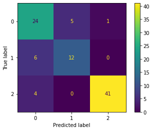

```python
plot_confusion_matrix(knn_model,scaled_X_test,y_test);
```

```python
print(classification_report(y_test,y_pred))
```

```
              precision    recall  f1-score   support

           0       0.71      0.80      0.75        30
           1       0.71      0.67      0.69        18
           2       0.98      0.91      0.94        45

    accuracy                           0.83        93
   macro avg       0.80      0.79      0.79        93
weighted avg       0.84      0.83      0.83        93
```

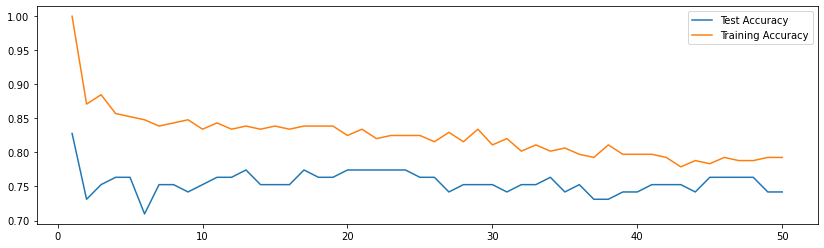

```python
# Training and test Accuracies when K is from 1 to 50
train_sc = []
test_sc = []
for i in range(1,51):
    knn_model = KNeighborsClassifier(n_neighbors=i)
    knn_model.fit(scaled_X_cv,y_cv)
    y_pred = knn_model.predict(scaled_X_test)

    train_acc_score = knn_model.score(scaled_X_cv,y_cv)
    train_sc.append(train_acc_score)

    test_acc_score = accuracy_score(y_test,y_pred)
    test_sc.append(test_acc_score)

plt.figure(figsize=(14,4))
plt.plot(range(1,51), test_sc, label = "Test Accuracy")
plt.plot(range(1,51), train_sc, label = "Training Accuracy")
plt.legend()
plt.show()
```

## It appears that the best accuracy is achieved when K = 1, however, we will run gridsearch to validate.

```python
# help(KNeighborsClassifier)
```

```python
X_cv, X_test, y_cv, y_test = train_test_split(X, y, test_size=0.2, random_state=42)
```

```python
# creating instances for normalization and model creation
knn = KNeighborsClassifier()
```

```python
# we will create a pipeline and define order of operations
operations = [('scaler',scaler),('knn',knn)]
from sklearn.pipeline import Pipeline
pipe = Pipeline(operations)
```

```python
from sklearn.model_selection import GridSearchCV
```

```python
k_values = list(range(1,51))
param_grid = {'knn__n_neighbors': k_values}
```

```python
full_cv_classifier = GridSearchCV(pipe,param_grid,cv=5,scoring='accuracy')
full_cv_classifier.fit(X_cv,y_cv)
```

```
GridSearchCV(cv=5,
             estimator=Pipeline(steps=[('scaler', StandardScaler()),
                                       ('knn', KNeighborsClassifier())]),
             param_grid={'knn__n_neighbors': [1, 2, 3, 4, 5, 6, 7, 8, 9, 10, 11,
                                              12, 13, 14, 15, 16, 17, 18, 19,
                                              20, 21, 22, 23, 24, 25, 26, 27,
                                              28, 29, 30, ...]},
             scoring='accuracy')
```

```python
# best k value
full_cv_classifier.best_estimator_.get_params()
```

```
{'memory': None,
 'steps': [('scaler', StandardScaler()), ('knn', KNeighborsClassifier())],
 'verbose': False,
 'scaler': StandardScaler(),
 'knn': KNeighborsClassifier(),
 'scaler__copy': True,
 'scaler__with_mean': True,
 'scaler__with_std': True,
 'knn__algorithm': 'auto',
 'knn__leaf_size': 30,
 'knn__metric': 'minkowski',
 'knn__metric_params': None,
 'knn__n_jobs': None,
 'knn__n_neighbors': 5,
 'knn__p': 2,
 'knn__weights': 'uniform'}
```

```python
full_cv_classifier.cv_results_['mean_test_score']
```

```
array([0.77812245, 0.77428571, 0.80661224, 0.81053061, 0.81869388,
       0.81461224, 0.80236735, 0.79020408, 0.80228571, 0.79444898,
       0.78620408, 0.78620408, 0.79428571, 0.80644898, 0.79036735,
       0.78620408, 0.79420408, 0.79004082, 0.79012245, 0.78204082,
       0.77804082, 0.78612245, 0.77004082, 0.76595918, 0.77412245,
       0.77804082, 0.78212245, 0.76595918, 0.77795918, 0.77395918,
       0.77004082, 0.76195918, 0.76995918, 0.75795918, 0.76987755,
       0.75787755, 0.77404082, 0.77004082, 0.78612245, 0.78236735,
       0.77820408, 0.77820408, 0.79036735, 0.78628571, 0.79028571,
       0.77804082, 0.77812245, 0.77820408, 0.77812245, 0.77820408])
```

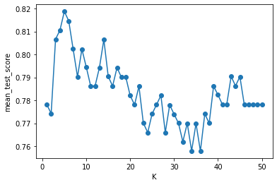

```python
scores = full_cv_classifier.cv_results_['mean_test_score']
plt.plot(k_values,scores,'o-')
plt.xlabel("K")
plt.ylabel("mean_test_score")
plt.show();
```

```python
print(f"The best K value as per the grid search is {full_cv_classifier.best_estimator_.get_params()['knn__n_neighbors']} and its mean test score is {max(full_cv_classifier.cv_results_['mean_test_score'])}")
```

```
The best K value as per the grid search is 5 and its mean test score is 0.8186938775510203
```

```python
pred = full_cv_classifier.predict(X_test)
```

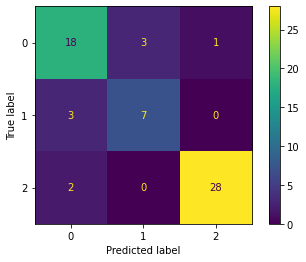

```python
plot_confusion_matrix(full_cv_classifier,X_test,y_test);
```

```python
print(classification_report(y_test,pred))
```

```
              precision    recall  f1-score   support

           0       0.78      0.82      0.80        22
           1       0.70      0.70      0.70        10
           2       0.97      0.93      0.95        30

    accuracy                           0.85        62
   macro avg       0.82      0.82      0.82        62
weighted avg       0.86      0.85      0.86        62
```

```python
print(f"Accuracy of Training Data: {full_cv_classifier.score(X_cv,y_cv)}")
print(f"Accuracy of Test Data: {full_cv_classifier.score(X_test,y_test)}")
```

```
Accuracy of Training Data: 0.8709677419354839
Accuracy of Test Data: 0.8548387096774194
```

1. Conclusion and improvisation:  
   • Write your conclusion on the results.  
   • Detailed suggestions or improvements or on quality, quantity, variety, velocity, veracity etc. on the data points  
   collected by the research team to perform a better data analysis in future.

Our model works best when K = 5 as we find the right balance between training and test accuracy. Having said that we must analyse more data so that the model can learn and our predictions can improve further. I would conclude that for a dataset of around 300 rows, this is a good prediction model. The challenges with the dataset is that there is very less data to learn from. THe quality of the data is good as we did not have to make lots of changes.